###PROBLEM STATEMENT #Part 1: Dimensionality Reduction

This section of the project entails reducing your dataset to a low dimensional dataset using the t-SNE algorithm or PCA. You will be required to perform your analysis and provide insights gained from your analysis.

#Part 2: Feature Selection

This section requires you to perform feature selection through the use of the unsupervised learning methods learned earlier this week. You will be required to perform your analysis and provide insights on the features that contribute the most information to the dataset.

#Part 3: Association Rules

This section will require that you create association rules that will allow you to identify relationships between variables in the dataset. You are provided with a separate dataset that comprises groups of items that will be associated with others. Just like in the other sections, you will also be required to provide insights for your analysis.

#Part 4: Anomaly Detection

You have also been requested to check whether there are any anomalies in the given sales dataset. The objective of this task being fraud detection.

```r
#Library loading
library(readr)
library(dplyr)
#read the files
getwd()
```

```
## [1] "/home/delilah"
```

```r
sales <- read.csv("supermarket1.csv")
sales
```

```
##       Invoice.ID Branch Customer.type Gender           Product.line Unit.price
## 1    750-67-8428      A        Member Female      Health and beauty      74.69
## 2    226-31-3081      C        Normal Female Electronic accessories      15.28
## 3    631-41-3108      A        Normal   Male     Home and lifestyle      46.33
## 4    123-19-1176      A        Member   Male      Health and beauty      58.22
## 5    373-73-7910      A        Normal   Male      Sports and travel      86.31
## 6    699-14-3026      C        Normal   Male Electronic accessories      85.39
## 7    355-53-5943      A        Member Female Electronic accessories      68.84
## 8    315-22-5665      C        Normal Female     Home and lifestyle      73.56
## 9    665-32-9167      A        Member Female      Health and beauty      36.26
## 10   692-92-5582      B        Member Female     Food and beverages      54.84
## 11   351-62-0822      B        Member Female    Fashion accessories      14.48
## 12   529-56-3974      B        Member   Male Electronic accessories      25.51
## 13   365-64-0515      A        Normal Female Electronic accessories      46.95
## 14   252-56-2699      A        Normal   Male     Food and beverages      43.19
```

[output cut: 2988 more lines]

##DATA PREPARATION

```r
dim(sales)
```

```
## [1] 1000   16
```

```r
#check datatypes
str(sales)
```

```
## 'data.frame':    1000 obs. of  16 variables:
##  $ Invoice.ID             : Factor w/ 1000 levels "101-17-6199",..: 815 143 654 19 340 734 316 265 703 727 ...
##  $ Branch                 : Factor w/ 3 levels "A","B","C": 1 3 1 1 1 3 1 3 1 2 ...
##  $ Customer.type          : Factor w/ 2 levels "Member","Normal": 1 2 2 1 2 2 1 2 1 1 ...
##  $ Gender                 : Factor w/ 2 levels "Female","Male": 1 1 2 2 2 2 1 1 1 1 ...
##  $ Product.line           : Factor w/ 6 levels "Electronic accessories",..: 4 1 5 4 6 1 1 5 4 3 ...
##  $ Unit.price             : num  74.7 15.3 46.3 58.2 86.3 ...
##  $ Quantity               : int  7 5 7 8 7 7 6 10 2 3 ...
##  $ Tax                    : num  26.14 3.82 16.22 23.29 30.21 ...
##  $ Date                   : Factor w/ 89 levels "1/1/2019","1/10/2019",..: 27 88 82 20 58 77 49 48 2 44 ...
##  $ Time                   : Factor w/ 506 levels "10:00","10:01",..: 147 24 156 486 30 394 215 78 342 160 ...
##  $ Payment                : Factor w/ 3 levels "Cash","Credit card",..: 3 1 2 3 3 3 3 3 2 2 ...
##  $ cogs                   : num  522.8 76.4 324.3 465.8 604.2 ...
##  $ gross.margin.percentage: num  4.76 4.76 4.76 4.76 4.76 ...
##  $ gross.income           : num  26.14 3.82 16.22 23.29 30.21 ...
##  $ Rating                 : num  9.1 9.6 7.4 8.4 5.3 4.1 5.8 8 7.2 5.9 ...
##  $ Total                  : num  549 80.2 340.5 489 634.4 ...
```

```r
summary(sales)
```

```
##        Invoice.ID  Branch  Customer.type    Gender
##  101-17-6199:  1   A:340   Member:501    Female:501
##  101-81-4070:  1   B:332   Normal:499    Male  :499
##  102-06-2002:  1   C:328
##  102-77-2261:  1
##  105-10-6182:  1
##  105-31-1824:  1
##  (Other)    :994
##                  Product.line   Unit.price       Quantity          Tax
##  Electronic accessories:170   Min.   :10.08   Min.   : 1.00   Min.   : 0.5085
##  Fashion accessories   :178   1st Qu.:32.88   1st Qu.: 3.00   1st Qu.: 5.9249
##  Food and beverages    :174   Median :55.23   Median : 5.00   Median :12.0880
##  Health and beauty     :152   Mean   :55.67   Mean   : 5.51   Mean   :15.3794
##  Home and lifestyle    :160   3rd Qu.:77.94   3rd Qu.: 8.00   3rd Qu.:22.4453
##  Sports and travel     :166   Max.   :99.96   Max.   :10.00   Max.   :49.6500
##
##         Date          Time            Payment         cogs
##  2/7/2019 : 20   14:42  :  7   Cash       :344   Min.   : 10.17
##  2/15/2019: 19   19:48  :  7   Credit card:311   1st Qu.:118.50
##  1/8/2019 : 18   17:38  :  6   Ewallet    :345   Median :241.76
##  3/14/2019: 18   10:11  :  5                     Mean   :307.59
##  3/2/2019 : 18   11:40  :  5                     3rd Qu.:448.90
##  1/23/2019: 17   11:51  :  5                     Max.   :993.00
##  (Other)  :890   (Other):965
##  gross.margin.percentage  gross.income         Rating           Total
##  Min.   :4.762           Min.   : 0.5085   Min.   : 4.000   Min.   :  10.68
##  1st Qu.:4.762           1st Qu.: 5.9249   1st Qu.: 5.500   1st Qu.: 124.42
##  Median :4.762           Median :12.0880   Median : 7.000   Median : 253.85
##  Mean   :4.762           Mean   :15.3794   Mean   : 6.973   Mean   : 322.97
##  3rd Qu.:4.762           3rd Qu.:22.4453   3rd Qu.: 8.500   3rd Qu.: 471.35
##  Max.   :4.762           Max.   :49.6500   Max.   :10.000   Max.   :1042.65
##
```

```r
# Checking for duplicated data
anyDuplicated(sales)
```

```
## [1] 0
```

```r
#no duplicated value
```

```r
colSums(is.na(sales))
```

```
##              Invoice.ID                  Branch           Customer.type
##                       0                       0                       0
##                  Gender            Product.line              Unit.price
##                       0                       0                       0
##                Quantity                     Tax                    Date
##                       0                       0                       0
##                    Time                 Payment                    cogs
##                       0                       0                       0
## gross.margin.percentage            gross.income                  Rating
##                       0                       0                       0
##                   Total
##                       0
```

```r
#no missing values
```

```r
#Check for outliers
library("ggplot2")
```

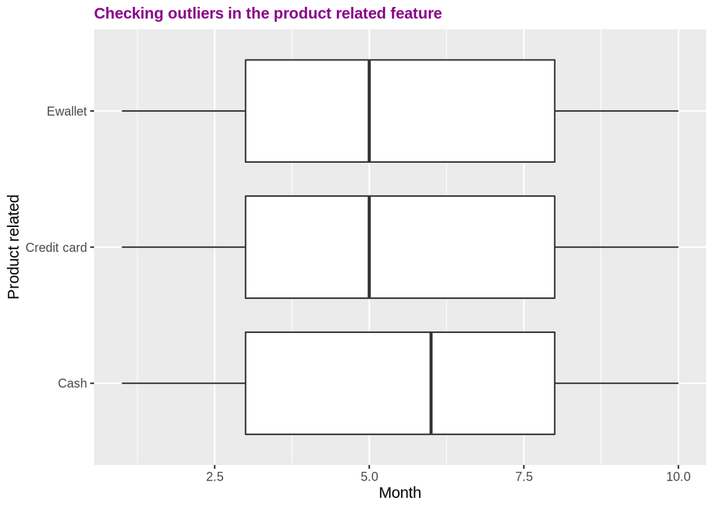

```r
options(repr.plot.width = 11, repr.plot.height = 5)
ggplot(sales, aes(Quantity,Payment, col =Rating )) +
  geom_boxplot() +
  labs(x = 'Month', y = 'Product related', title = 'Checking outliers in the product related feature') +
  theme(legend.position = 'top', legend.text = element_text(size = 10),
       plot.title = element_text(size = 11, color = 'darkmagenta', face = 'bold'))
```

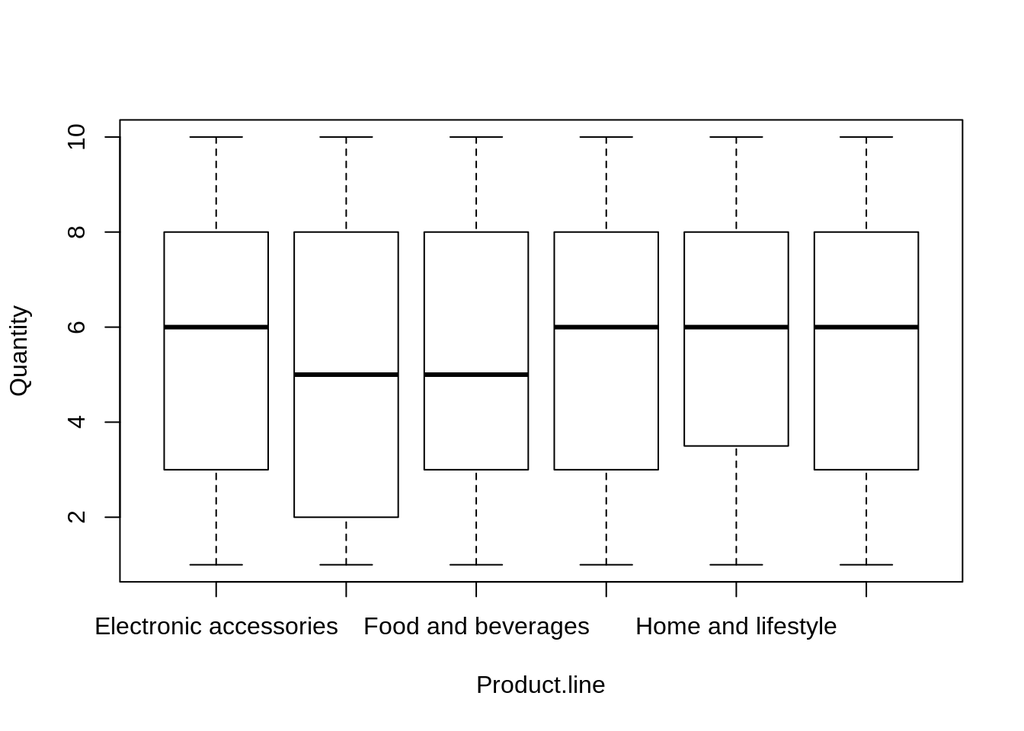

```r
#check for outliers
  boxplot(Quantity~Product.line,data=sales)
```

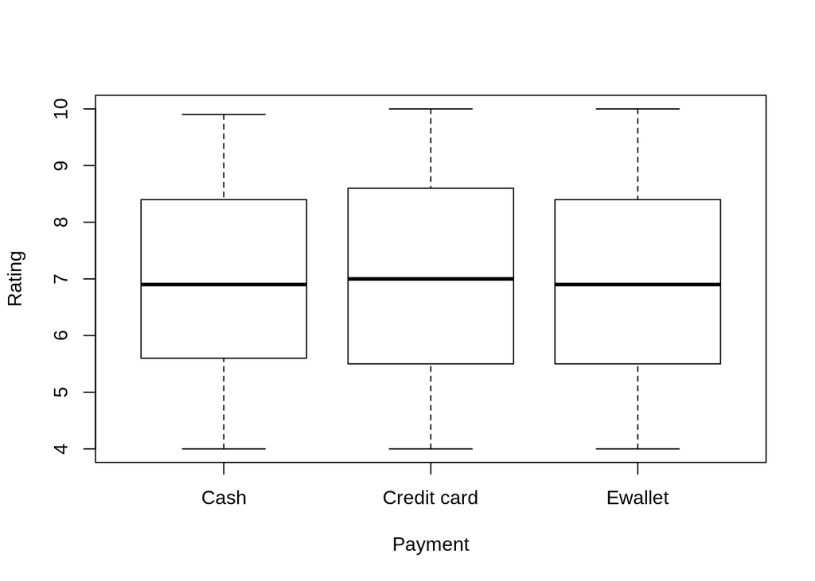

```r
  boxplot(Rating~Payment,data=sales)
```

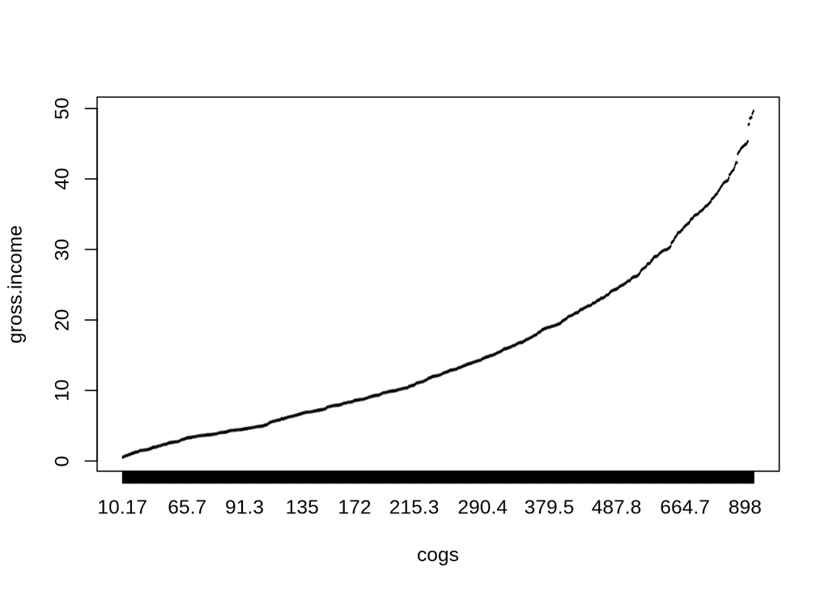

```r
 boxplot(gross.income~cogs,data=sales)
```

#UNIVARIATE ANALYSIS

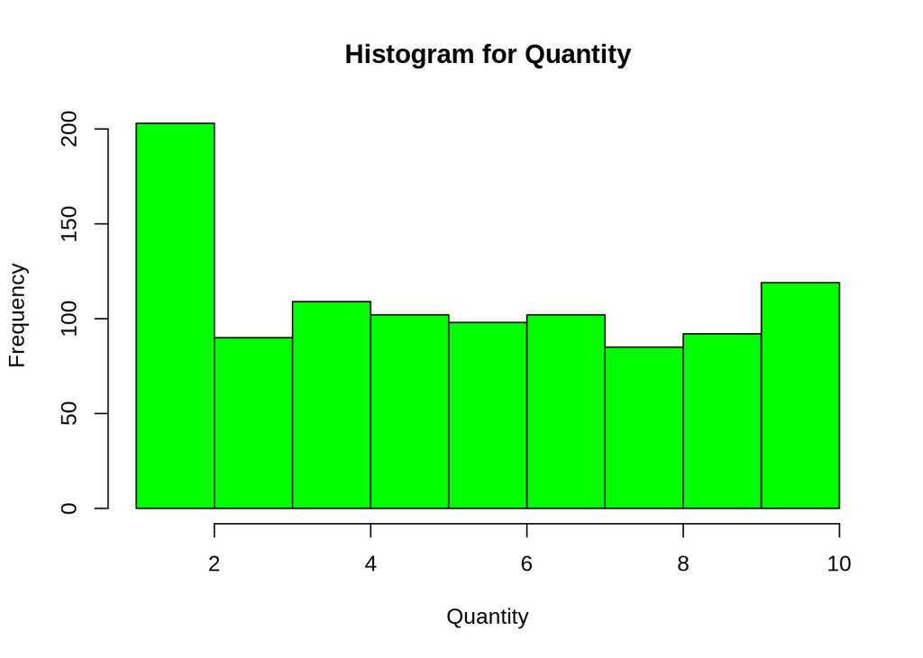

```r
hist(sales$Quantity,
     main="Histogram for Quantity",
     xlab="Quantity",
     border="black",
     col="green")
```